# Census 2022

Some initial thoughts

Paul Kilgarriff

2023-06-16

## Ireland Census 2022

With the release of the first set of summary results on the 30th May, I look at some of the main trends that are taking place. I focus in particular on change in population and households and also the composition of households.

## Housing Tenure

Figure 1 shows the breakdown of the share of the four housing tenures by local authority and regional grouping.

#### Figure 1: Census 2022 Housing Tenure.

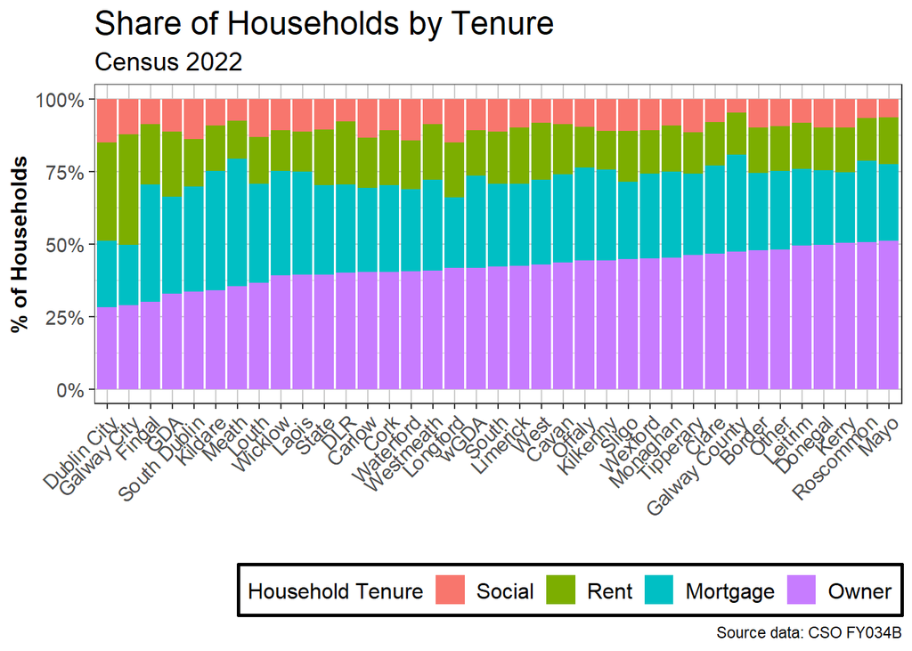

One of the most interesting initial findings is the current trend of a decreasing share of mortgage holders. Easy access to credit in the 90’s and 00’s, led to an increase in the number of mortgage holders. With the introduction of macro-prudential rules, we are not witnessing the same levels of credit that ultimately lead to the Irish banking crisis post-2008.

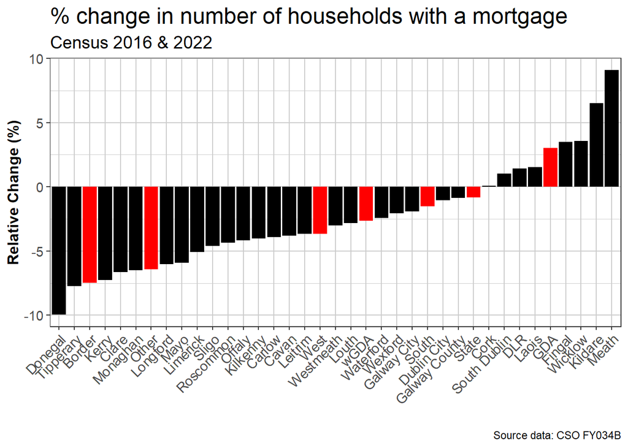